# 7Assignment7.code

```
Project Name     : Trends in Cellular Subscriptions
Programmer Name  : Htet Phyo Wai
Superviser       : Dr.Edward Mirielli
Class            : Intro to Data Science and Analytics(Fall,2018)

Description      :
```

The goal of this projet is to make comparative analysis of cellular subscriptions in different regions of the world by applying data analytic practices - data cleaning, manipulation, and visualtaion techniques - using Python.

### Data Analytics Process Summary

1) Data Cleaning : Checking any missing value, filling them with 0

2) Data Preparation: Grouping the countries by Geographic Region : Group by Year (setting the starting year as 1980)

3) Summary Statistics : values in the possible range; what can we infered from the (example) Summary Statistics of East Asia and Pacific

```
                    (2011-2017)
                    ---
                    count 3.700000e+01
                    std 2.108336e+08
                    min 0.000000e+00
                    25% 5.571329e+04
                    50% 1.487345e+06
                    75% 2.542871e+07
                    MAX 1.249233e+09
                    name: YG2011_17Avg, dtype: float64
```

4) Construct new dataframes of all yeargroups for each region.  
(visulaization)

```
   Figure - Year Group Comparison of East Asia Pacific Region
```

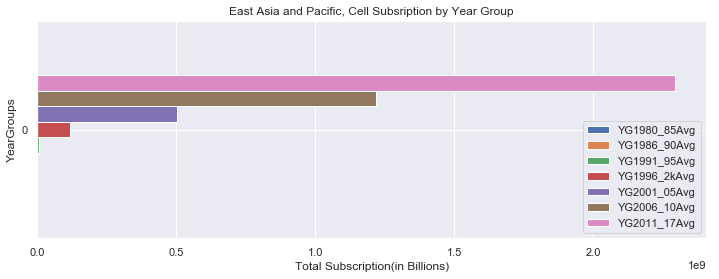

[output not shown]

```python
EAPaggregate_by_yr
```

|  | YG1980_85Avg | YG1986_90Avg | YG1991_95Avg | YG1996_2kAvg | YG2001_05Avg | YG2006_10Avg | YG2011_17Avg |
| --- | --- | --- | --- | --- | --- | --- | --- |
| 0 | 28608.0 | 642670.0 | 9241725.4 | 117939693.6 | 504019604.8 | 1.220106e+09 | 2.291736e+09 |

5) Next Step: Construct new dataframes to compare regional subscriptions for each yeargroup.

```
                                1980-1985
```

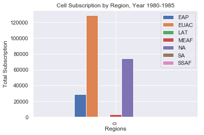

```
                                2001-2005
```

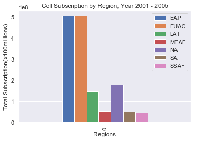

```
                                2011-2017
```

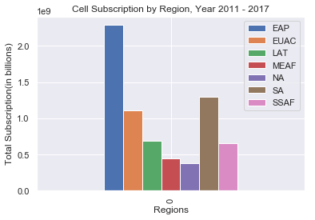

Take Away: Cellular Subscription of certain region(East Asia/ Sout Asia) increase more significantly than others.

Side Note: DECIDING WHICH COUNTRIES IN EACH REGION HAS HIGHEST MOBILE SUBSCRIPTION

- *Europe*
- 1980: Finlad has the highest cellular subscription.
- 1989: UK has the highest cell subscription :2nd Sweden 3rd Finland
- 2017: Russia(227341873) Germany(106000000), Italy(83871543), UK (79173658)
- *East ASia and Pacific*
- 1989: Japan (489558) Australia (94529) Hong Kong (89193)
- 2000: China (85260000 ) Japan (66784374) Korea (26816398)
- 2017: China(1474097000) Indonesia(458923202)Japan(170128499)Thailand(121530000)
- *NorthAmerica*
- 2017: US (395881000) Canada (31458600)

### Concluding Remark

In early 2000s, Asia Pacific region emerged as the major cellular subscribers equalizing with Europe Region when both region share 504 million users respectively. China contributed the most in increasing the subscriber user base in year 2000 when two state-run companies-China Telecom and China Netcom- began their operations. From early 2000 to mid 2000s, every region across the world also experienced rapid increase in subscription when the connectivity of internet broadband networks from mobile devices became widespread.

The functionality of mobile devices, particulary in the moblile application development, have improved over the period. As Network-based Mobile games and the Social Network became popular, the subscription of cellular networks continue to expand. As of 2017, East Asia and Pacific region followed by South Asia region become the major subscribers surpassing EU and North America regions that dominated the market historically. Among all countries, China has the largest subscribed user followed by India, Indonesia and U.S in 2017. In Europe, Russia has the highest cellular subscription overtaking Western European Countries and Scandinavian neighbours. It is important to note that having high density of cellular usage in those countries may not represent higher investment or advancement in mobile technology. Moreover, the underlying reasons of rapid cellular subscription in some countries are beyond the scope of this study. Possible explanations include government incentives, income level, the pricing strategies of mobile providers and technology services culture in selected countries which require further analysis.

```
             Figure: Cellular Subscription by Country (2017)
```

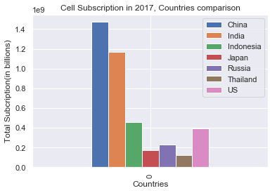

```python
# CODES START HERE

%matplotlib inline
import pandas as pd
import matplotlib.pyplot as plt
import seaborn as sns
import numpy as np
sns.set(style="darkgrid")
```

```python
#DATA CLEANGING _ EXTRACTING DATA

CellSubscribeData = pd.read_csv('Y:/fa2018-csc300dsa/completed/Assignment7/CellSubscriptionxData.csv',index_col = 0,encoding='ISO-8859-1')
CSMetaData = pd.read_csv('Y:/fa2018-csc300dsa/completed/Assignment7/CellSubscriptionxMETAD.csv'  ,index_col = 0, encoding='ISO-8859-1')

#Note:
#The above data is obtained from World Bank Organization
#https://data.worldbank.org/indicator/IT.CEL.SETS
# 'CellSubscrideData' contians subscription data from 1960 to 2017
#  for every countries.
# 'CSMetaData' contains the information about each country such as
#  the regions they are in and high income/low income indicators.
```

```python
#### CHECKING DATA TYPES, MISSING VALUES, ETC..

CellSubscribeData.head()
#CSMetaData.head()
#CellSubscribeData.dtypes
#CSMetaData.dtypes
#CellSubscribeData.columns
#CSMetaData.columns
```

| Country Name | Country Code | Indicator Name | Indicator Code | 1960 | 1961 | 1962 | 1963 | 1964 | 1965 | 1966 | ... | 2008 | 2009 | 2010 | 2011 | 2012 | 2013 | 2014 | 2015 | 2016 | 2017 |
| --- | --- | --- | --- | --- | --- | --- | --- | --- | --- | --- | --- | --- | --- | --- | --- | --- | --- | --- | --- | --- | --- |
| Aruba | ABW | Mobile cellular subscriptions | IT.CEL.SETS | 0.0 | NaN | NaN | NaN | NaN | 0.0 | NaN | ... | 120806.0 | 128000.0 | 131800.0 | NaN | 135000.0 | 138800.0 | 139700.0 | 141000.0 | NaN | NaN |
| Afghanistan | AFG | Mobile cellular subscriptions | IT.CEL.SETS | 0.0 | NaN | NaN | NaN | NaN | 0.0 | NaN | ... | 7898909.0 | 10500000.0 | 10215840.0 | 13797879.0 | 15340115.0 | 16807156.0 | 18407168.0 | 19709038.0 | 21602982.0 | 23929713.0 |
| Angola | AGO | Mobile cellular subscriptions | IT.CEL.SETS | 0.0 | NaN | NaN | NaN | NaN | 0.0 | NaN | ... | 6773356.0 | 8109421.0 | 9403365.0 | 12073218.0 | 12785109.0 | 13285198.0 | 14052558.0 | 13884532.0 | 13001124.0 | 13323952.0 |
| Albania | ALB | Mobile cellular subscriptions | IT.CEL.SETS | 0.0 | NaN | NaN | NaN | NaN | 0.0 | NaN | ... | 1859632.0 | 2463741.0 | 2692372.0 | 3100000.0 | 3500000.0 | 3685983.0 | 3359654.0 | 3400955.0 | 3369756.0 | 3497950.0 |
| Andorra | AND | Mobile cellular subscriptions | IT.CEL.SETS | 0.0 | NaN | NaN | NaN | NaN | 0.0 | NaN | ... | 64202.0 | 64549.0 | 65495.0 | 65044.0 | 63865.0 | 63931.0 | 66241.0 | 71336.0 | 76132.0 | 80337.0 |

5 rows × 61 columns

```python
#DATA CLEANING _ COMBINING DATA

df = CellSubscribeData.merge(CSMetaData, left_on = 'Country Code', right_on ='Country Code', how = 'outer')
df = df.fillna(0)
#df
#df.describe()
```

```python
# DATA PREPARATION TASK : Group by Geographic Regions

EAsiaPacific =  df.loc [df['Region'] == 'East Asia & Pacific']
EuropeCAsia = df.loc [df['Region'] == 'Europe & Central Asia']
LatinAmerica = df.loc [df['Region'] == 'Latin America & Caribbean']
MEastNAfrica = df.loc [df['Region'] == 'Middle East & North Africa']
NorthAmerica = df.loc [df['Region'] == 'North America']
SouthAsia = df.loc [df['Region'] == 'South Asia']
SubSahAfrica = df.loc [df['Region'] == 'Sub-Saharan Africa']
```

```python
EAsiaPacific.head()
```

|  | Country Code | Indicator Name | Indicator Code | 1960 | 1961 | 1962 | 1963 | 1964 | 1965 | 1966 | ... | 2012 | 2013 | 2014 | 2015 | 2016 | 2017 | Region | IncomeGroup | SpecialNotes | TableName |
| --- | --- | --- | --- | --- | --- | --- | --- | --- | --- | --- | --- | --- | --- | --- | --- | --- | --- | --- | --- | --- | --- |
| 9 | ASM | Mobile cellular subscriptions | IT.CEL.SETS | 0.0 | 0.0 | 0.0 | 0.0 | 0.0 | 0.0 | 0.0 | ... | 0.000000e+00 | 0.000000e+00 | 0.000000e+00 | 0.000000e+00 | 0.000000e+00 | 0.000000e+00 | East Asia & Pacific | Upper middle income | New base Year 2009 | American Samoa |
| 11 | AUS | Mobile cellular subscriptions | IT.CEL.SETS | 0.0 | 0.0 | 0.0 | 0.0 | 0.0 | 0.0 | 0.0 | ... | 2.433800e+07 | 2.494000e+07 | 2.506000e+07 | 2.577000e+07 | 2.655100e+07 | 2.755300e+07 | East Asia & Pacific | High income | Fiscal year end: June 30; reporting period for... | Australia |
| 29 | BRN | Mobile cellular subscriptions | IT.CEL.SETS | 0.0 | 0.0 | 0.0 | 0.0 | 0.0 | 0.0 | 0.0 | ... | 4.697400e+05 | 4.688140e+05 | 4.520540e+05 | 4.633840e+05 | 5.234530e+05 | 5.447320e+05 | East Asia & Pacific | High income | National accounts revision is based on data fr... | Brunei Darussalam |
| 38 | CHN | Mobile cellular subscriptions | IT.CEL.SETS | 0.0 | 0.0 | 0.0 | 0.0 | 0.0 | 0.0 | 0.0 | ... | 1.112155e+09 | 1.229113e+09 | 1.286093e+09 | 1.291984e+09 | 1.364934e+09 | 1.474097e+09 | East Asia & Pacific | Upper middle income | On 1 July 1997 China resumed its exercise of s... | China |
| 74 | FJI | Mobile cellular subscriptions | IT.CEL.SETS | 0.0 | 0.0 | 0.0 | 0.0 | 0.0 | 0.0 | 0.0 | ... | 8.588090e+05 | 9.304060e+05 | 8.761760e+05 | 9.659500e+05 | 1.044685e+06 | 1.033915e+06 | East Asia & Pacific | Upper middle income | National accounts have been revised based on ... | Fiji |

5 rows × 65 columns

```python
## DATA PREPARATION :: GROUP BY YEAR - STARTING YEAR

# We will use 1980 as starting year since there is no cellur subscription in all countries
#from the beginning of 1960 to 1979

df= df.loc[:,'1980': 'TableName']
#df
```

```python
#GROUP BY YEARGROUP

YG1980to85 = df.loc[:,['TableName','1980','1981','1982','1983','1984','1985']].groupby('TableName').mean()
YG1980to85['YG1980_85Avg']= YG1980to85.mean(axis=1)

YG1986to90 = df.loc[:,['TableName','1986', '1987', '1988','1989', '1990']].groupby('TableName').mean()
YG1986to90['YG1986_90Avg']= YG1986to90.mean(axis=1)

YG1991to95 = df.loc[:,['TableName','1991', '1992', '1993', '1994', '1995']].groupby('TableName').mean()
YG1991to95['YG1991_95Avg']= YG1991to95.mean(axis=1)

YG1996to2k = df.loc[:,['TableName','1996', '1997','1998', '1999', '2000']].groupby('TableName').mean()
YG1996to2k['YG1996_2kAvg']= YG1996to2k.mean(axis=1)

YG2001to05 = df.loc[:,['TableName','2001', '2002', '2003', '2004', '2005']].groupby('TableName').mean()
YG2001to05['YG2001_05Avg']= YG2001to05.mean(axis=1)

YG2006to10 = df.loc[:,['TableName','2006','2007', '2008', '2009', '2010']].groupby('TableName').mean()
YG2006to10['YG2006_10Avg']= YG2006to10.mean(axis=1)

YG2011to17 = df.loc[:,['TableName','2011', '2012', '2013', '2014', '2015','2016', '2017']].groupby('TableName').mean()
YG2011to17['YG2011_17Avg']= YG2011to17.mean(axis=1)
```

```python
#DESCRIPTIC STATISTICS FOR AGGREGATE YEARGROUP+GEOGRAPHICREGION

#EAsiaPacific

EAP8085 = pd.merge( EAsiaPacific[['TableName']],YG1980to85,on='TableName',how = 'left')
#print("---\nSummary Statistics, East Asia and Pacific(1980-85)\n---\n",EAP8085['YG1980_85Avg'].describe())

EAP8690 = pd.merge( EAsiaPacific[['TableName']],YG1986to90,on='TableName', how = 'left')
#print("---\nSummary Statistics, East Asia and Pacific(1986-90)\n---\n",EAP8690['YG1986_90Avg'].describe())

EAP9195 = pd.merge( EAsiaPacific[['TableName']],YG1991to95,on='TableName', how = 'left')
#print("---\nSummary Statistics, East Asia and Pacific(1991-95)\n---\n",EAP9195['YG1991_95Avg'].describe())

EAP962k = pd.merge( EAsiaPacific[['TableName']],YG1996to2k,on='TableName', how = 'left')
#print("---\nSummary Statistics, East Asia and Pacific(1996-2k)\n---\n",EAP962k['YG1996_2kAvg'].describe())

EAP0105 = pd.merge( EAsiaPacific[['TableName']],YG2001to05,on='TableName', how = 'left')
#print("---\nSummary Statistics, East Asia and Pacific(2001-05)\n---\n",EAP0105['YG2001_05Avg'].describe())

EAP0610 = pd.merge( EAsiaPacific[['TableName']],YG2006to10,on='TableName', how = 'left')
#print("---\nSummary Statistics, East Asia and Pacific(2006-10)\n---\n",EAP0610['YG2006_10Avg'].describe())

EAP1117 = pd.merge( EAsiaPacific[['TableName']],YG2011to17,  on='TableName',  how = 'left')
print("---\nSummary Statistics, East Asia and Pacific(2011-17)\n---\n",EAP1117['YG2011_17Avg'].describe())
```

```
---
Summary Statistics, East Asia and Pacific(2011-17)
---
 count    3.700000e+01
mean     6.193881e+07
std      2.108336e+08
min      0.000000e+00
25%      5.571329e+04
50%      1.487345e+06
75%      2.542871e+07
max      1.249233e+09
Name: YG2011_17Avg, dtype: float64
```

```python
#EuropeCAsia
EUCA8085 = pd.merge( EuropeCAsia[['TableName']],YG1980to85,on='TableName',how = 'left')
#print("---\nSummary Statistics, EuropeCAsia(1980-85)\n---\n",EAP8085['YG1980_85Avg'].describe())
EUCA8690 = pd.merge( EuropeCAsia[['TableName']],YG1986to90,on='TableName', how = 'left')
#print("---\nSummary Statistics, EuropeCAsia(1986-90)\n---\n",EAP8690['YG1986_90Avg'].describe())
EUCA9195 = pd.merge( EuropeCAsia[['TableName']],YG1991to95,on='TableName', how = 'left')
#print("---\nSummary Statistics, EuropeCAsia(1991-95)\n---\n",EAP9195['YG1991_95Avg'].describe())
EUCA962k = pd.merge( EuropeCAsia[['TableName']],YG1996to2k,on='TableName', how = 'left')
#print("---\nSummary Statistics, EuropeCAsia(1996-2k)\n---\n",EAP962k['YG1996_2kAvg'].describe())
EUCA0105 = pd.merge( EuropeCAsia[['TableName']],YG2001to05,on='TableName', how = 'left')
#print("---\nSummary Statistics, EuropeCAsia(2001-05)\n---\n",EAP0105['YG2001_05Avg'].describe())
EUCA0610 = pd.merge( EuropeCAsia[['TableName']],YG2006to10,on='TableName', how = 'left')
#print("---\nSummary Statistics, EuropeCAsia(2006-10)\n---\n",EAP0610['YG2006_10Avg'].describe())
EUCA1117 = pd.merge( EuropeCAsia[['TableName']],YG2011to17,  on='TableName',  how = 'left')
#print("---\nSummary Statistics, EuropeCAsia(2011-17)\n---\n",EAP1117['YG2011_17Avg'].describe())

#LatinAmerica
LAT8085 = pd.merge( LatinAmerica[['TableName']],YG1980to85,on='TableName',how = 'left')
#print("---\nSummary Statistics, LatinAmerica(1980-85)\n---\n",EAP8085['YG1980_85Avg'].describe())
LAT8690 = pd.merge( LatinAmerica[['TableName']],YG1986to90,on='TableName', how = 'left')
#print("---\nSummary Statistics, LatinAmerica(1986-90)\n---\n",EAP8690['YG1986_90Avg'].describe())
LAT9195 = pd.merge( LatinAmerica[['TableName']],YG1991to95,on='TableName', how = 'left')
#print("---\nSummary Statistics, LatinAmerica(1991-95)\n---\n",EAP9195['YG1991_95Avg'].describe())
LAT962k = pd.merge( LatinAmerica[['TableName']],YG1996to2k,on='TableName', how = 'left')
#print("---\nSummary Statistics, LatinAmerica(1996-2k)\n---\n",EAP962k['YG1996_2kAvg'].describe())
LAT0105 = pd.merge( LatinAmerica[['TableName']],YG2001to05,on='TableName', how = 'left')
#print("---\nSummary Statistics, LatinAmerica(2001-05)\n---\n",EAP0105['YG2001_05Avg'].describe())
LAT0610 = pd.merge( LatinAmerica[['TableName']],YG2006to10,on='TableName', how = 'left')
#print("---\nSummary Statistics, LatinAmerica(2006-10)\n---\n",EAP0610['YG2006_10Avg'].describe())
LAT1117 = pd.merge( LatinAmerica[['TableName']],YG2011to17,  on='TableName',  how = 'left')
#print("---\nSummary Statistics, LatinAmerica(2011-17)\n---\n",EAP1117['YG2011_17Avg'].describe())

#MEastNAfrica
MEAF8085 = pd.merge( MEastNAfrica[['TableName']],YG1980to85,on='TableName',how = 'left')
#print("---\nSummary Statistics, MEastNAfrica(1980-85)\n---\n",EAP8085['YG1980_85Avg'].describe())
MEAF8690 = pd.merge( MEastNAfrica[['TableName']],YG1986to90,on='TableName', how = 'left')
#print("---\nSummary Statistics, MEastNAfrica(1986-90)\n---\n",EAP8690['YG1986_90Avg'].describe())
MEAF9195 = pd.merge( MEastNAfrica[['TableName']],YG1991to95,on='TableName', how = 'left')
#print("---\nSummary Statistics, MEastNAfrica(1991-95)\n---\n",EAP9195['YG1991_95Avg'].describe())
MEAF962k = pd.merge( MEastNAfrica[['TableName']],YG1996to2k,on='TableName', how = 'left')
#print("---\nSummary Statistics, MEastNAfrica(1996-2k)\n---\n",EAP962k['YG1996_2kAvg'].describe())
MEAF0105 = pd.merge( MEastNAfrica[['TableName']],YG2001to05,on='TableName', how = 'left')
#print("---\nSummary Statistics, MEastNAfrica(2001-05)\n---\n",EAP0105['YG2001_05Avg'].describe())
MEAF0610 = pd.merge( MEastNAfrica[['TableName']],YG2006to10,on='TableName', how = 'left')
#print("---\nSummary Statistics, MEastNAfrica(2006-10)\n---\n",EAP0610['YG2006_10Avg'].describe())
MEAF1117 = pd.merge( MEastNAfrica[['TableName']],YG2011to17,  on='TableName',  how = 'left')
#print("---\nSummary Statistics, MEastNAfrica(2011-17)\n---\n",EAP1117['YG2011_17Avg'].describe())

#NorthAmerica
NA8085 = pd.merge( NorthAmerica[['TableName']],YG1980to85,on='TableName',how = 'left')
#print("---\nSummary Statistics, NorthAmerica (1980-85)\n---\n",EAP8085['YG1980_85Avg'].describe())
NA8690 = pd.merge( NorthAmerica[['TableName']],YG1986to90,on='TableName', how = 'left')
#print("---\nSummary Statistics, NorthAmerica (1986-90)\n---\n",EAP8690['YG1986_90Avg'].describe())
NA9195 = pd.merge( NorthAmerica[['TableName']],YG1991to95,on='TableName', how = 'left')
#print("---\nSummary Statistics,NorthAmerica (1991-95)\n---\n",EAP9195['YG1991_95Avg'].describe())
NA962k = pd.merge( NorthAmerica[['TableName']],YG1996to2k,on='TableName', how = 'left')
#print("---\nSummary Statistics, NorthAmerica (1996-2k)\n---\n",EAP962k['YG1996_2kAvg'].describe())
NA0105 = pd.merge( NorthAmerica[['TableName']],YG2001to05,on='TableName', how = 'left')
#print("---\nSummary Statistics, NorthAmerica (2001-05)\n---\n",EAP0105['YG2001_05Avg'].describe())
NA0610 = pd.merge( NorthAmerica[['TableName']],YG2006to10,on='TableName', how = 'left')
#print("---\nSummary Statistics,NorthAmerica (2006-10)\n---\n",EAP0610['YG2006_10Avg'].describe())
NA1117 = pd.merge( NorthAmerica[['TableName']],YG2011to17,  on='TableName',  how = 'left')
#print("---\nSummary Statistics, NorthAmerica (2011-17)\n---\n",EAP1117['YG2011_17Avg'].describe())

#SouthAsia
SA8085 = pd.merge( SouthAsia[['TableName']],YG1980to85,on='TableName',how = 'left')
#print("---\nSummary Statistics, SouthAsia(1980-85)\n---\n",EAP8085['YG1980_85Avg'].describe())
SA8690 = pd.merge( SouthAsia[['TableName']],YG1986to90,on='TableName', how = 'left')
#print("---\nSummary Statistics, SouthAsia(1986-90)\n---\n",EAP8690['YG1986_90Avg'].describe())
SA9195 = pd.merge( SouthAsia[['TableName']],YG1991to95,on='TableName', how = 'left')
#print("---\nSummary Statistics, SouthAsia(1991-95)\n---\n",EAP9195['YG1991_95Avg'].describe())
SA962k = pd.merge( SouthAsia[['TableName']],YG1996to2k,on='TableName', how = 'left')
#print("---\nSummary Statistics,SouthAsia(1996-2k)\n---\n",EAP962k['YG1996_2kAvg'].describe())
SA0105 = pd.merge( SouthAsia[['TableName']],YG2001to05,on='TableName', how = 'left')
#print("---\nSummary Statistics, SouthAsia(2001-05)\n---\n",EAP0105['YG2001_05Avg'].describe())
SA0610 = pd.merge( SouthAsia[['TableName']],YG2006to10,on='TableName', how = 'left')
#print("---\nSummary Statistics, SouthAsia(2006-10)\n---\n",EAP0610['YG2006_10Avg'].describe())
SA1117 = pd.merge( SouthAsia[['TableName']],YG2011to17,  on='TableName',  how = 'left')
#print("---\nSummary Statistics, SouthAsia(2011-17)\n---\n",EAP1117['YG2011_17Avg'].describe())

#SubSahAfrica
SSAF8085 = pd.merge( SubSahAfrica[['TableName']],YG1980to85,on='TableName',how = 'left')
#print("---\nSummary Statistics, SubSahAfrica(1980-85)\n---\n",EAP8085['YG1980_85Avg'].describe())
SSAF8690 = pd.merge( SubSahAfrica[['TableName']],YG1986to90,on='TableName', how = 'left')
#print("---\nSummary Statistics,SubSahAfrica(1986-90)\n---\n",EAP8690['YG1986_90Avg'].describe())
SSAF9195 = pd.merge( SubSahAfrica[['TableName']],YG1991to95,on='TableName', how = 'left')
#print("---\nSummary Statistics, SubSahAfrica(1991-95)\n---\n",EAP9195['YG1991_95Avg'].describe())
SSAF962k = pd.merge( SubSahAfrica[['TableName']],YG1996to2k,on='TableName', how = 'left')
#print("---\nSummary Statistics, SubSahAfrica(1996-2k)\n---\n",EAP962k['YG1996_2kAvg'].describe())
SSAF0105 = pd.merge( SubSahAfrica[['TableName']],YG2001to05,on='TableName', how = 'left')
#print("---\nSummary Statistics, SubSahAfrica(2001-05)\n---\n",EAP0105['YG2001_05Avg'].describe())
SSAF0610 = pd.merge( SubSahAfrica[['TableName']],YG2006to10,on='TableName', how = 'left')
#print("---\nSummary Statistics, SubSahAfrica(2006-10)\n---\n",EAP0610['YG2006_10Avg'].describe())
SSAF1117 = pd.merge( SubSahAfrica[['TableName']],YG2011to17,  on='TableName',  how = 'left')
#print("---\nSummary Statistics, SubSahAfrica(2011-17)\n---\n",EAP1117['YG2011_17Avg'].describe())
```

```
Text(0,0.5,'YearGroups')
```

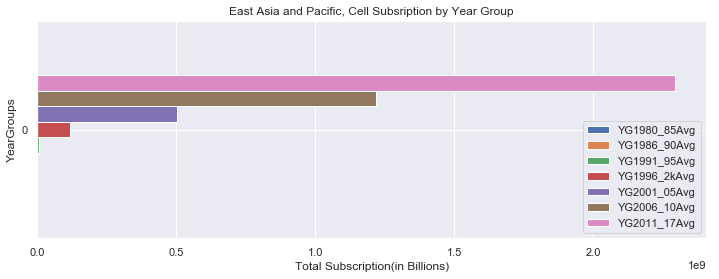

```python
# We make a new data frame to compare aggregate data of each region
#   for their respective year groups.
EAPaggdata = {'YG1980_85Avg':[ EAP8085['YG1980_85Avg'].sum()],
                     'YG1986_90Avg':[EAP8690['YG1986_90Avg'].sum()],
                     'YG1991_95Avg':[EAP9195['YG1991_95Avg'].sum()],
                     'YG1996_2kAvg':[EAP962k['YG1996_2kAvg'].sum()],
                    'YG2001_05Avg': [EAP0105['YG2001_05Avg'].sum()],
                    'YG2006_10Avg': [EAP0610['YG2006_10Avg'].sum()],
                     'YG2011_17Avg':[EAP1117['YG2011_17Avg'].sum()]}

EAPaggregate_by_yr = pd.DataFrame(data = EAPaggdata)
ax = EAPaggregate_by_yr.plot( kind = 'barh',figsize = (12,4), legend = True, title="East Asia and Pacific, Cell Subsription by Year Group")
ax.set_xlabel('Total Subscription(in Billions)')
ax.set_ylabel('YearGroups')
```

```python
EAPaggregate_by_yr
```

|  | YG1980_85Avg | YG1986_90Avg | YG1991_95Avg | YG1996_2kAvg | YG2001_05Avg | YG2006_10Avg | YG2011_17Avg |
| --- | --- | --- | --- | --- | --- | --- | --- |
| 0 | 28608.0 | 642670.0 | 9241725.4 | 117939693.6 | 504019604.8 | 1.220106e+09 | 2.291736e+09 |

```python
EUCAaggregatedata = {'YG1980_85Avg':[ EUCA8085['YG1980_85Avg'].sum()],
                     'YG1986_90Avg':[EUCA8690['YG1986_90Avg'].sum()],
                     'YG1991_95Avg':[EUCA9195['YG1991_95Avg'].sum()],
                     'YG1996_2kAvg':[EUCA962k['YG1996_2kAvg'].sum()],
                    'YG2001_05Avg': [EUCA0105['YG2001_05Avg'].sum()],
                    'YG2006_10Avg': [EUCA0610['YG2006_10Avg'].sum()],
                     'YG2011_17Avg':[EUCA1117['YG2011_17Avg'].sum()]}
EUCAaggregate_by_yr = pd.DataFrame(data = EUCAaggregatedata)

LATaggregatedata = {'YG1980_85Avg':[LAT8085['YG1980_85Avg'].sum()],
                     'YG1986_90Avg':[LAT8690['YG1986_90Avg'].sum()],
                     'YG1991_95Avg':[LAT9195['YG1991_95Avg'].sum()],
                     'YG1996_2kAvg':[LAT962k['YG1996_2kAvg'].sum()],
                    'YG2001_05Avg': [LAT0105['YG2001_05Avg'].sum()],
                    'YG2006_10Avg': [LAT0610['YG2006_10Avg'].sum()],
                     'YG2011_17Avg':[LAT1117['YG2011_17Avg'].sum()]}
LATaggregate_by_yr = pd.DataFrame(data = LATaggregatedata)

MEAFaggregatedata = {'YG1980_85Avg':[ MEAF8085['YG1980_85Avg'].sum()],
                     'YG1986_90Avg':[MEAF8690['YG1986_90Avg'].sum()],
                     'YG1991_95Avg':[MEAF9195['YG1991_95Avg'].sum()],
                     'YG1996_2kAvg':[MEAF962k['YG1996_2kAvg'].sum()],
                    'YG2001_05Avg': [MEAF0105['YG2001_05Avg'].sum()],
                    'YG2006_10Avg': [MEAF0610['YG2006_10Avg'].sum()],
                     'YG2011_17Avg':[MEAF1117['YG2011_17Avg'].sum()]}
MEAFaggregate_by_yr = pd.DataFrame(data = MEAFaggregatedata)

NAaggregatedata = {'YG1980_85Avg':[ NA8085['YG1980_85Avg'].sum()],
                     'YG1986_90Avg':[NA8690['YG1986_90Avg'].sum()],
                     'YG1991_95Avg':[NA9195['YG1991_95Avg'].sum()],
                     'YG1996_2kAvg':[NA962k['YG1996_2kAvg'].sum()],
                    'YG2001_05Avg': [NA0105['YG2001_05Avg'].sum()],
                    'YG2006_10Avg': [NA0610['YG2006_10Avg'].sum()],
                     'YG2011_17Avg':[NA1117['YG2011_17Avg'].sum()]}
NAaggregate_by_yr = pd.DataFrame(data = NAaggregatedata)

SAaggregatedata = {'YG1980_85Avg':[ SA8085['YG1980_85Avg'].sum()],
                     'YG1986_90Avg':[SA8690['YG1986_90Avg'].sum()],
                     'YG1991_95Avg':[SA9195['YG1991_95Avg'].sum()],
                     'YG1996_2kAvg':[SA962k['YG1996_2kAvg'].sum()],
                    'YG2001_05Avg': [SA0105['YG2001_05Avg'].sum()],
                    'YG2006_10Avg': [SA0610['YG2006_10Avg'].sum()],
                     'YG2011_17Avg':[SA1117['YG2011_17Avg'].sum()]}
SAaggregate_by_yr = pd.DataFrame(data = SAaggregatedata)

SSAFaggregatedata = {'YG1980_85Avg':[ SSAF8085['YG1980_85Avg'].sum()],
                     'YG1986_90Avg':[SSAF8690['YG1986_90Avg'].sum()],
                     'YG1991_95Avg':[SSAF9195['YG1991_95Avg'].sum()],
                     'YG1996_2kAvg':[SSAF962k['YG1996_2kAvg'].sum()],
                    'YG2001_05Avg': [SSAF0105['YG2001_05Avg'].sum()],
                    'YG2006_10Avg': [SSAF0610['YG2006_10Avg'].sum()],
                     'YG2011_17Avg':[SSAF1117['YG2011_17Avg'].sum()]}
SSAFaggregate_by_yr = pd.DataFrame(data = SSAFaggregatedata)
```

```python
#EUCAaggregate_by_yr.plot(kind='barh',title="Europe-Central Asia, Cell Subsription by Year Group")
```

```python
EUCAaggregate_by_yr
```

|  | YG1980_85Avg | YG1986_90Avg | YG1991_95Avg | YG1996_2kAvg | YG2001_05Avg | YG2006_10Avg | YG2011_17Avg |
| --- | --- | --- | --- | --- | --- | --- | --- |
| 0 | 128840.833333 | 1808510.0 | 11902856.2 | 135124486.6 | 504855184.0 | 981933875.6 | 1.112111e+09 |

```python
#LATaggregate_by_yr.plot(kind='barh',title="Latin America, Cell Subsription by Year Group")
```

```python
LATaggregate_by_yr
```

|  | YG1980_85Avg | YG1986_90Avg | YG1991_95Avg | YG1996_2kAvg | YG2001_05Avg | YG2006_10Avg | YG2011_17Avg |
| --- | --- | --- | --- | --- | --- | --- | --- |
| 0 | 0.0 | 34474.8 | 1652807.4 | 28907009.4 | 145641119.0 | 447465437.6 | 6.847087e+08 |

```python
#MEAFaggregate_by_yr.plot(kind='barh',title="Middle East and Africa, Cell Subsription by Year Group")
```

```python
MEAFaggregate_by_yr
```

|  | YG1980_85Avg | YG1986_90Avg | YG1991_95Avg | YG1996_2kAvg | YG2001_05Avg | YG2006_10Avg | YG2011_17Avg |
| --- | --- | --- | --- | --- | --- | --- | --- |
| 0 | 3134.333333 | 51320.8 | 400685.8 | 6509971.6 | 52642964.4 | 252358932.2 | 4.399310e+08 |

```python
#NAaggregate_by_yr.plot(kind='barh',title="North America, Cell Subsription by Year Group")
```

```python
NAaggregate_by_yr
```

|  | YG1980_85Avg | YG1986_90Avg | YG1991_95Avg | YG1996_2kAvg | YG2001_05Avg | YG2006_10Avg | YG2011_17Avg |
| --- | --- | --- | --- | --- | --- | --- | --- |
| 0 | 73968.833333 | 2813183.6 | 20025730.8 | 78564617.0 | 177497930.6 | 282147720.0 | 3.780865e+08 |

```python
#SAaggregate_by_yr.plot(kind='barh',title="SouthAsia, Cell Subsription by Year Group")
```

```python
SAaggregate_by_yr
```

|  | YG1980_85Avg | YG1986_90Avg | YG1991_95Avg | YG1996_2kAvg | YG2001_05Avg | YG2006_10Avg | YG2011_17Avg |
| --- | --- | --- | --- | --- | --- | --- | --- |
| 0 | 0.0 | 602.0 | 56857.8 | 2089412.4 | 48905652.0 | 548146285.6 | 1.298625e+09 |

```python
#SSAFaggregate_by_yr.plot(kind='barh',title="SubSahara Africa, Cell Subsription by Year Group")
```

```python
SSAFaggregate_by_yr
```

|  | YG1980_85Avg | YG1986_90Avg | YG1991_95Avg | YG1996_2kAvg | YG2001_05Avg | YG2006_10Avg | YG2011_17Avg |
| --- | --- | --- | --- | --- | --- | --- | --- |
| 0 | 0.0 | 2372.0 | 212092.4 | 4991042.0 | 44482755.6 | 257180970.2 | 6.494671e+08 |

```
Text(0,0.5,'Total Subscription')
```

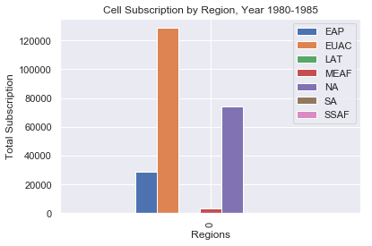

```python
# Creating Dataframes by  YearGroups to compare the Regions

d1 ={'EAP':[EAP8085['YG1980_85Avg'].sum()],
    'EUAC':[EUCA8085['YG1980_85Avg'].sum()],
    'LAT':[LAT8085['YG1980_85Avg'].sum()],
    'MEAF':[MEAF8085['YG1980_85Avg'].sum()],
    'NA':[NA8085['YG1980_85Avg'].sum()],
    'SA':[SA8085['YG1980_85Avg'].sum()],
    'SSAF':[SSAF8085['YG1980_85Avg'].sum()]}
dff1 = pd.DataFrame(data = d1)
fig = dff1.plot(kind='bar',title ="Cell Subscription by Region, Year 1980-1985")
fig.set_xlabel('Regions')
fig.set_ylabel('Total Subscription')
```

```python
dff1
#dff1.drop(['NA','EUAC',],axis =1).plot(kind='bar')
```

|  | EAP | EUAC | LAT | MEAF | NA | SA | SSAF |
| --- | --- | --- | --- | --- | --- | --- | --- |
| 0 | 28608.0 | 128840.833333 | 0.0 | 3134.333333 | 73968.833333 | 0.0 | 0.0 |

```python
d2 ={'EAP':[EAP8690['YG1986_90Avg'].sum()],
    'EUAC':[EUCA8690['YG1986_90Avg'].sum()],
    'LAT':[LAT8690['YG1986_90Avg'].sum()],
    'MEAF':[MEAF8690['YG1986_90Avg'].sum()],
    'NA':[NA8690['YG1986_90Avg'].sum()],
    'SA':[SA8690['YG1986_90Avg'].sum()],
    'SSAF':[SSAF8690['YG1986_90Avg'].sum()]}
dff2 = pd.DataFrame(data = d2)
#dff2.plot(kind='bar',title ="Cell Subscription by Region, Year 1986-1990")
```

```python
dff2
```

|  | EAP | EUAC | LAT | MEAF | NA | SA | SSAF |
| --- | --- | --- | --- | --- | --- | --- | --- |
| 0 | 642670.0 | 1808510.0 | 34474.8 | 51320.8 | 2813183.6 | 602.0 | 2372.0 |

```python
#dff.drop(['NA'],axis =1).plot(kind='bar')
```

```
Text(0,0.5,'Total Subscription(x100millions)')
```

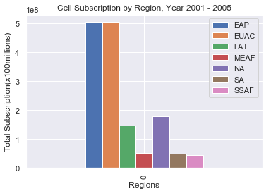

```python
d3={'EAP':[EAP0105['YG2001_05Avg'].sum()],
    'EUAC':[EUCA0105['YG2001_05Avg'].sum()],
    'LAT':[LAT0105['YG2001_05Avg'].sum()],
    'MEAF':[MEAF0105['YG2001_05Avg'].sum()],
    'NA':[NA0105['YG2001_05Avg'].sum()],
    'SA':[SA0105['YG2001_05Avg'].sum()],
    'SSAF':[SSAF0105['YG2001_05Avg'].sum()]}
dff3 = pd.DataFrame(data = d3)
fig = dff3.plot(kind='bar',title ="Cell Subscription by Region, Year 2001 - 2005")
fig.set_xlabel('Regions')
fig.set_ylabel('Total Subscription(x100millions)')
```

```python
dff3
```

|  | EAP | EUAC | LAT | MEAF | NA | SA | SSAF |
| --- | --- | --- | --- | --- | --- | --- | --- |
| 0 | 504019604.8 | 504855184.0 | 145641119.0 | 52642964.4 | 177497930.6 | 48905652.0 | 44482755.6 |

```python
d4={'EAP':[EAP0610['YG2006_10Avg'].sum()],
    'EUAC':[EUCA0610['YG2006_10Avg'].sum()],
    'LAT':[LAT0610['YG2006_10Avg'].sum()],
    'MEAF':[MEAF0610['YG2006_10Avg'].sum()],
    'NA':[NA0610['YG2006_10Avg'].sum()],
    'SA':[SA0610['YG2006_10Avg'].sum()],
    'SSAF':[SSAF0610['YG2006_10Avg'].sum()]}
dff4 = pd.DataFrame(data = d4)
#dff4.plot(kind='bar',title ="Cell Subscription by Region, Year 1986-1990")
```

```
Text(0,0.5,'Total Subscription(in billions)')
```

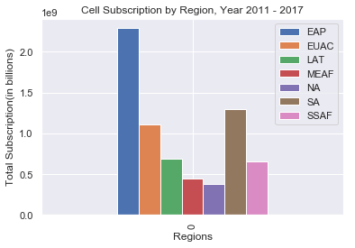

```python
d5={'EAP':[EAP1117['YG2011_17Avg'].sum()],
    'EUAC':[EUCA1117['YG2011_17Avg'].sum()],
    'LAT':[LAT1117['YG2011_17Avg'].sum()],
    'MEAF':[MEAF1117['YG2011_17Avg'].sum()],
    'NA':[NA1117['YG2011_17Avg'].sum()],
    'SA':[SA1117['YG2011_17Avg'].sum()],
    'SSAF':[SSAF1117['YG2011_17Avg'].sum()]}
dff5 = pd.DataFrame(data = d5)
fig = dff5.plot.bar(title ="Cell Subscription by Region, Year 2011 - 2017")
fig.set_xlabel('Regions')
fig.set_ylabel('Total Subscription(in billions)')
```

```python
#DECIDING WHICH COUNTRIES IN EACH REGION HAS HIGHEST MOBILE SUBSCRIPTION

#EuropeCAsia
#EuropeCAsia = EuropeCAsia[(EuropeCAsia.TableName != 'United Kingdom')]
#EuropeCAsia = EuropeCAsia[(EuropeCAsia.TableName != 'Sweden')]
#EuropeCAsia['1989'].argmax()

# Summary: In 1989, UK has the highest cell cellscription :2nd Sweden /3rd Finland
# In 2017, Russia(227341873) Germany(106000000), Italy(83871543), UK (79173658)
#EAsiaPacific (Region with highest Subscription)
#Code :
#EAsiaPacific = EAsiaPacific[(EAsiaPacific.TableName != 'China')]
#EAsiaPacific = EAsiaPacific[(EAsiaPacific.TableName != 'Japan')]
#EAsiaPacific['2017'].argmax()

#Summary:
#1989 : Japan (489558) Australia (94529) Hong Kong (89193)
#2000 : China (85260000 ) Japan (66784374) Korea (26816398)
#2017: China(1474097000) Indonesia(458923202)Japan(170128499)Thailand(121530000)

#LatinAmerica
#Code :
#LatinAmerica['2017'].argmax()
#Summary:
#      2017: Brazil 236488548

#NorthAmerica
#Summary:
#      2017 : US (395881000) Canada (31458600)
#      2017 : India(1168902277)
```

```
Text(0,0.5,'Total Subcription(in billions)')
```

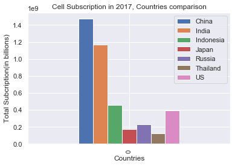

```python
# Dataframe for Countries with high Subscription Rate in East Asia/ Pacific Region
#  (comparing with countries from second and third highest subscribed Regions)

d={ 'India' :1168902277,
   'China':1474097000,
   'Indonesia':458923202,
   'Japan':170128499,
   'Thailand':121530000,
   'Russia' : 227341873,
  #'Germany' : 106000000,
  # 'Italy' : 83871543,
  # 'UK' : 79173658,
    'US' :395881000,
  #  'Canada' :31458600,
  # 'Brazil': 236488548,
  }
dff = pd.DataFrame(data = d, index=[0])
ax = dff.plot.bar(title ="Cell Subscription in 2017, Countries comparison")
ax.set_xlabel('Countries')
ax.set_ylabel('Total Subcription(in billions)')
```

References:

General

https://data.worldbank.org/indicator/IT.CEL.SETS?end=2017&locations=1W&start=1960&type=points&view=chart

http://www.atechnologysociety.co.uk/advances-mobile-phones.html

https://www.economist.com/business/2009/03/05/boom-in-the-bust

https://www.economist.com/business/2009/03/05/priming-the-pipe

2000/mid2000(NA)

http://citeseerx.ist.psu.edu/viewdoc/download?doi=10.1.1.642.7969&rep=rep1&type=pdf

https://www.telegraph.co.uk/finance/personalfinance/comment/4457372/Wap-bop-alubop-a-mobile-boom.html

Asia

https://www2.deloitte.com/content/dam/Deloitte/sg/Documents/technology-media-telecommunications/sea-tmt-2017-global-mobile-consumer-survey-sea-edition.pdf

(SEA)

https://www.economist.com/business/2010/08/19/talk-is-cheap

(SA) https://asia.nikkei.com/Economy/India-s-mobile-internet-boom-goes-supersonic2